# MLEbin_recommend

Andrew Edwards

## Recommended fitting and plotting approach for data that are binned (with just one set of bin breaks)

```r
library(sizeSpectra)
# library(tibble)  # Else prints all of a tibble
```

This vignette is for data that are only available in standard binned form, with one set of bin breaks (unlike the overlapping species-specific bins shown in MEPS Fig. 7). For example, zooplankton data available in bins that progressively double in bin width. Or, data that are only available in digitised form from earlier papers.

This vignette shows how to fit the PLB disribution (using the MLEbin method) and plot it in a similar way to the MEPS Fig. 7. The plotting is done using the new function `ISD_bin_plot_nonoverlapping()`, which is a wrapper for the more complex (and slightly updated) `ISD_bin_plot()`.

Note: this is not (yet) part of any publication and so has not been peer-reviewed, it’s just exploring some potentially useful plotting approaches.

### Simulate and fit data

First, generate some data from a true PLB distribution and bin it (using bin widths that double in size):

```r
set.seed(42)
x <- rPLB(n = 1000,
          b = -2,
          xmin = 1,
          xmax = 1000)

x.binned <- binData(x,
                    binWidth = "2k")  # 1, 2, 5 or "2k"

head(x.binned$indiv)     # Individual x values and which bin they are assigned to
```

```
#>           x binMid binMin binMax
#> 1 11.613220   12.0      8     16
#> 2 15.658847   12.0      8     16
#> 3  1.400273    1.5      1      2
#> 4  5.869136    6.0      4      8
#> 5  2.786321    3.0      2      4
#> 6  2.077175    3.0      2      4
```

```r
x.binned$binVals         # Bins and the counts in each bin (with extra columns
```

```
#> # A tibble: 9 × 13
#>   binMid binMin binMax binWidth binCount binCou…¹ binSum binSu…² log10…³ log10…⁴
#>    <dbl>  <dbl>  <dbl>    <dbl>    <int>    <dbl>  <dbl>   <dbl>   <dbl>   <dbl>
#> 1    1.5      1      2        1      528  5.28e+2   733.  733.     0.176   2.72
#> 2    3        2      4        2      228  1.14e+2   632.  316.     0.477   2.36
#> 3    6        4      8        4      113  2.82e+1   610.  152.     0.778   2.05
#> 4   12        8     16        8       75  9.38e+0   859.  107.     1.08    1.88
#> 5   24       16     32       16       33  2.06e+0   718.   44.9    1.38    1.52
#> 6   48       32     64       32       14  4.38e-1   641.   20.0    1.68    1.15
#> 7   96       64    128       64        6  9.38e-2   618.    9.65   1.98    0.778
#> 8  192      128    256      128        2  1.56e-2   425.    3.32   2.28    0.301
#> 9  384      256    512      256        1  3.91e-3   399.    1.56   2.58    0
#> # … with 3 more variables: log10binSum <dbl>, log10binCountNorm <dbl>,
#> #   log10binSumNorm <dbl>, and abbreviated variable names ¹binCountNorm,
#> #   ²binSumNorm, ³log10binMid, ⁴log10binCount
```

```r
                         #  that we won't need here).
```

Now fit the PLB distribution using the MLEbin method. The fitting function takes the binned data as two vectors (the bin breaks and the counts in each bin):

```r
num.bins <- nrow(x.binned$binVals)

# bin breaks are the minima plus the max of the final bin:
binBreaks <- c(dplyr::pull(x.binned$binVals, binMin),
               dplyr::pull(x.binned$binVals, binMax)[num.bins])

binCounts <- dplyr::pull(x.binned$binVals, binCount)

MLEbin.res <-  calcLike(negLL.fn = negLL.PLB.binned,
                        p = -1.5,
                        w = binBreaks,
                        d = binCounts,
                        J = length(binCounts),   # = num.bins
                        vecDiff = 1)             # increase this if hit a bound
```

```
#> Warning in nlm(f = negLL.fn, p = p, ...): NA/Inf replaced by maximum positive
#> value
```

The `NA/Inf replaced by maximum positive value` warnings are fine - the likelihood function is blowing up in a very unlikely region of parameter space.

### Plot the data and the fit like in MEPS Fig. 7

Now plot the data and results using:

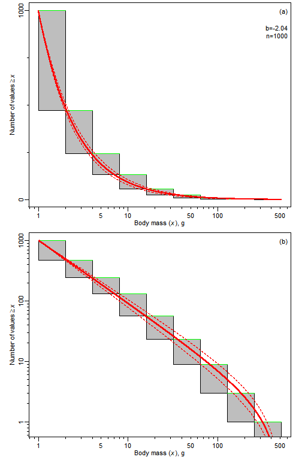

```r
# fig.width is 0.67 * fig.height (which is 8)
ISD_bin_plot_nonoverlapping(binBreaks = binBreaks,
                            binCounts = binCounts,
                            b.MLE = MLEbin.res$MLE,
                            b.confMin = MLEbin.res$conf[1],
                            b.confMax = MLEbin.res$conf[2])
```

The text in (a) gives the MLE for the size-spectrum exponent $b$, and the sample size $n$.

Both figures show that the PLB distribution is an excellent fit for these data the red curves go through the top-left and bottom-right corners of the grey boxes. Of course, the data are simulated from a PLB distribution and so should be a good fit, but these figures show the benefit of the plotting approach (which may not have been so obvious in MEPS Fig. 7 for data with a complex bin structure).

### Plotting the data if stored as a tibble

Real data can either input to the plotting function in the above form - a vector `binBreaks` of breakpoints and a vector `binCounts` of counts in each bin, or as a tibble.

If you prefer keeping your binned data as a tibble, then you can use the tible in the call to the plotting function (though you do still need to input the data as two vectors in the `calcLike` call above). This gives the same figures:

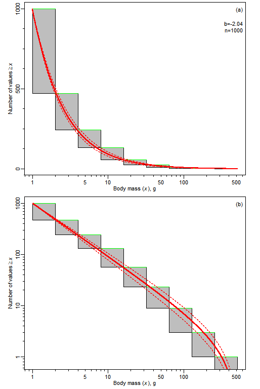

```r
ISD_bin_plot_nonoverlapping(binValsTibble = x.binned$binVals,
                            b.MLE = MLEbin.res$MLE,
                            b.confMin = MLEbin.res$conf[1],
                            b.confMax = MLEbin.res$conf[2],
                            yBig.inc = 500)
```

## LBN plot if data are body-masses

In MEE Fig. 6 we recommended, for body-mass data, showing the biomass size spectrum, as people are used to seeing this type of plot. If body-mass data are only available in binned form (as here), then this would be particularly appropriate. The fit is calculated using likelihood, but then shown on the biomass size spectrum.

Here, we introduce a modified version of MEE Fig 6(a). In that figure the normalised biomass in each bin (the total biomass in a bin divided by its bin width) was shown as a single point, as has been traditional in such figures. However, this does not explicitly show the true width of the bin, and ignores the uncertainty in the total biomass (that arises due to the binning).

Consider an example bin range from 15 to 20 g, with a count of 30 individuals. The possible range of the *total* biomass of those 30 individuals is therefore 450 to 600 g, and the normalised biomass (dividing the total biomass by the bin width) is 90 to 120.

More generally, following the notation in MEE Section A.1.7, bin $j$ covers values of $x$ (body masses) in the interval $[w_j, w_{j+1})$, and contains $d_j$ individuals. So the total biomass in bin $j$ is in the range $[d_j w_j, d_j w_{j+1})$. The normalised biomass in the bin (of width $w_{j+1} - w_j$), is therefore in the range $d_j w_j /(w_{j+1} - w_j)$ to $d_j w_{j+1} / (w_{j+1} - w_j)$. We express this as the vertical extent of the grey box for each bin in the figures below.

The horizontal range of each bin is simply shown as the horizontal extent of the grey box for that bin; for bin $j$ this is simply $w_j$ to $w_{j+1}$, as in the above figures.

We present three options, depending on whether axes are logged or not.

Neither axis logged:

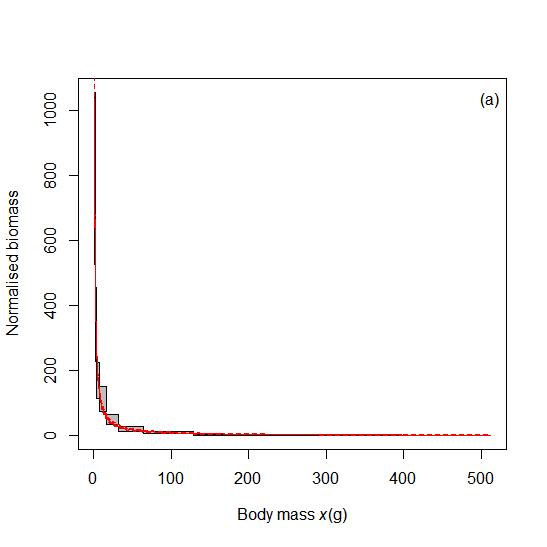

```r
LBN_bin_plot(binValsTibble = x.binned$binVals,
             b.MLE = MLEbin.res$MLE,
             b.confMin = MLEbin.res$conf[1],
             b.confMax = MLEbin.res$conf[2],
             log.xy = "",
             plot.binned.fitted = FALSE)
```

This is clearly hard to see, hence motivates logging the x-axis:

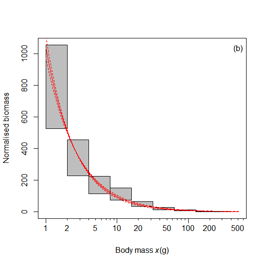

```r
LBN_bin_plot(binValsTibble = x.binned$binVals,
             b.MLE = MLEbin.res$MLE,
             b.confMin = MLEbin.res$conf[1],
             b.confMax = MLEbin.res$conf[2],
             leg.text = "(b)",
             log.xy = "x",
             plot.binned.fitted = FALSE)
```

This is easier to see and shows the good fit to the data, though it is harder to see the high body-mass bins that have low normalised biomass in them. The grey boxes show (horizontally) the range of each bin, and (vertically) the possible range in normalised biomass for that bin, given the data. The red solid curve fits through the boxes; dashed lines are the PLB distribution with $b$ set to the limits of the 95% confidence interval (calculated using likelihood).

So log both axes (which is analogous to the traditional LBN plot, like in MEE Fig. 6):

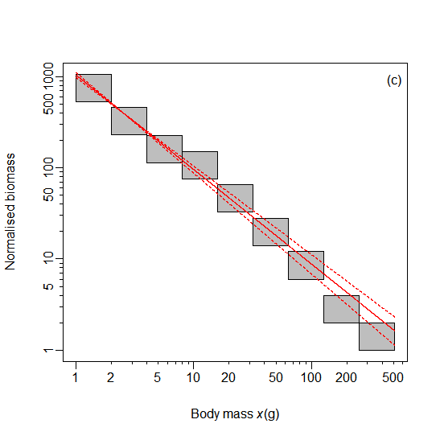

```r
LBN_bin_plot(binValsTibble = x.binned$binVals,
             b.MLE = MLEbin.res$MLE,
             b.confMin = MLEbin.res$conf[1],
             b.confMax = MLEbin.res$conf[2],
             leg.text = "(c)",
             log.xy = "xy",
             plot.binned.fitted = FALSE)
```

The fit is really good for the numerous small individuals, less so for the larger rare individuals. The log-log axes do emphasise the relatively poorer fit of the larger body sizes, but there are few individuals here. The red lines are all straight because of the log-log axes, but are calculated using likelihood, not regression (which would be the LBNbiom method).

Since the data are only available in binned form, the straight red lines are, upon reflection, not actually the most intuitive things to plot. So next we estimate the expected normalised biomass in each bin based on the MLE for $b$ (giving the horizontal red bars) and the confidence limits for $b$ (giving the pink rectangles, slightly shortened horizontally to still show the grey rectangles):

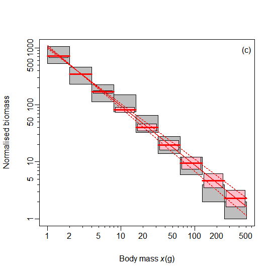

```r
LBN_bin_plot(binValsTibble = x.binned$binVals,
             b.MLE = MLEbin.res$MLE,
             b.confMin = MLEbin.res$conf[1],
             b.confMax = MLEbin.res$conf[2],
             leg.text = "(c)",
             log.xy = "xy",
             plot.binned.fitted = TRUE)
```

A useful thing will be to create movie where the fit is for incrementally higher values of $x_{min}$

### Larger confidence interval curiosity

Just curious to see what the figure looks like with a confidence interval for $b$ that’s set to twice as wide as the actual one (fixing the interval here by adding half the width to each side):

```r
confWidth <- diff(MLEbin.res$conf)
confWidth
```

```
#> [1] 0.135
```

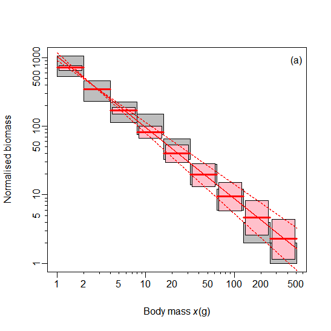

```r
LBN_bin_plot(binValsTibble = x.binned$binVals,
             b.MLE = MLEbin.res$MLE,
             b.confMin = MLEbin.res$conf[1] - confWidth/2,
             b.confMax = MLEbin.res$conf[2] + confWidth/2)
```

But, now there’s no real reason to label the axes with logged values, rather than use the more intuitive actual values (still on a log scale).